# MT5761 Individual Project

200029834

## INTRODUCTION :

The purpose of the individual project is to clean two data-sets which will later allow us to compare them and combine their data in a way where we will be able to obtain important information. In the project we are required to use version control system called ‘git’ and create a report using R Markdown.

During the process of the project we will be working with 2 specific data sets (CSV files.)

- BikeSeoul.csv
- BikeWashingtonDC.csv

These two data sets contain the number of bikes rented at each hour in each of the continents/states. In the beginning the two given data sets are “messy”/not clean . In the project we will apply Data Wrangling to the data, resulting in having a “tidy”/clean data set. Once the files are in the correct format, we will create different plots to explore the relationships between rented bikes in Washington, D.C., USA with Seoul, South Korea . We will also use the plots to examine if these numbers are determined by the weather conditions (Humidity, Temperature, Wind Speed). Once we visualize all these summaries, we will apply statistical analysis on the data to understand the relationship of the data even more and predict future outcomes.  
The given techniques will be applied on the two CSV files data:

- Data Wrangling
- Data Visualisation
- Statistical modelling

## DATA WRANGLING :

### Seoul, South Korea Data File beginning state

```r
seoul_Bikes <- read.csv("BikeSeoul.csv")
head(seoul_Bikes)
```

```
##         Date Rented.Bike.Count Hour Temperature.C. Humidity... Wind.speed..m.s.
## 1 01/12/2017               254    0           -5.2          37              2.2
## 2 01/12/2017               204    1           -5.5          38              0.8
## 3 01/12/2017               173    2           -6.0          39              1.0
## 4 01/12/2017               107    3           -6.2          40              0.9
## 5 01/12/2017                78    4           -6.0          36              2.3
## 6 01/12/2017               100    5           -6.4          37              1.5
##   Visibility..10m. Dew.point.temperature.C. Solar.Radiation..MJ.m2.
## 1             2000                    -17.6                       0
## 2             2000                    -17.6                       0
## 3             2000                    -17.7                       0
## 4             2000                    -17.6                       0
## 5             2000                    -18.6                       0
## 6             2000                    -18.7                       0
##   Rainfall.mm. Snowfall..cm. Seasons    Holiday Functioning.Day
## 1            0             0  Winter No Holiday             Yes
## 2            0             0  Winter No Holiday             Yes
## 3            0             0  Winter No Holiday             Yes
## 4            0             0  Winter No Holiday             Yes
## 5            0             0  Winter No Holiday             Yes
## 6            0             0  Winter No Holiday             Yes
```

Above we can see the beginning state of the file(“BikeSeoul.csv”). We can notice that their are some issues with the Data Structure of the data set.

- Column names are too long [Rented.Bike.Count, Solar.Radiation..MJ.m2., …]
- Unclear column names (too much notation that creates confusion) [Dew.point.temperature.C. ,]
- Values are too long and take more time to code [‘No Holiday’]

These problems create clutter in the data and make it harder for us to understand it. In the first glimpse the data is difficult to read and extract estimates.

#### [TASK 1]

Our first task in our Data Wrangling is to remove all the rows that indicate a bike was not rented, after remove the column ‘Functioning Day’ which specifies this data.  
**Implemantation idea**  
Column ‘Functioning Day’ states if a bike was rented or not. We will have to filter through the rows and obtaining the records that have value “Yes” for attribute ‘Functioning Day’. These are the records that a bike was rented. Once we have obtained these rows we can remove the column ‘Functioning Day’.

```r
## Number of rows before removing unneeded records are:
nrow(seoul_Bikes)
```

```
## [1] 8760
```

```r
seoul_Bikes <- seoul_Bikes %>%
  filter(Functioning.Day != "No") %>% ## Collect rows with value Yes in column Functioning.Day
  select(-Functioning.Day) ## Remove column Functioning.Day
## Number of rows after removing unneeded records are:
nrow(seoul_Bikes)
```

```
## [1] 8465
```

#### [TASK 2]

Our second task is to rename some column names to more appropriate ones.  
From our first glimpse of the table we can notice that some column names do not have appropriate names.

- ‘Rented.Bike.Count’ to ‘Count’
- ‘Temperature.C.’ to ‘Temperature’
- ‘Wind.speed..m.s.’ to ‘WindSpeed’
- ‘Seasons’ to ‘Season’
- ‘Humidity…’ to ‘Humidity’

**Implemantation idea**  
Using function rename() from tidyverse we can simply rename the column names to more appropriate ones.

```r
## Header Names before Renaming
names(seoul_Bikes)
```

```
##  [1] "Date"                     "Rented.Bike.Count"
##  [3] "Hour"                     "Temperature.C."
##  [5] "Humidity..."              "Wind.speed..m.s."
##  [7] "Visibility..10m."         "Dew.point.temperature.C."
##  [9] "Solar.Radiation..MJ.m2."  "Rainfall.mm."
## [11] "Snowfall..cm."            "Seasons"
## [13] "Holiday"
```

```r
seoul_Bikes <- seoul_Bikes %>%
  rename(Count = Rented.Bike.Count, ## Using function we are renaming the columns.
         Temperature = Temperature.C.,
         WindSpeed = Wind.speed..m.s.,
         Season = Seasons,
         Humidity = Humidity...)
## Header Names after Renaming
names(seoul_Bikes)
```

```
##  [1] "Date"                     "Count"
##  [3] "Hour"                     "Temperature"
##  [5] "Humidity"                 "WindSpeed"
##  [7] "Visibility..10m."         "Dew.point.temperature.C."
##  [9] "Solar.Radiation..MJ.m2."  "Rainfall.mm."
## [11] "Snowfall..cm."            "Season"
## [13] "Holiday"
```

#### [TASK 3]

Our third task is to convert column Date from type ‘character’ to type to ‘Date’.  
**Implemantation idea**  
With the help of tidyverse function ‘as_date()’ we will change the type/class of the attribute.

```r
## Printing class of column Date before mutation.
class(seoul_Bikes$Date)
```

```
## [1] "character"
```

```r
seoul_Bikes <- seoul_Bikes %>%
  convertDate("dmy")
## Printing class of column Date after mutation.
class(seoul_Bikes$Date)
```

```
## [1] "Date"
```

#### [TASK 4]

Our fourth task is to add a new column with name ‘FullDate’ which will hold the Date and Hour of the day the bike was rented in format ‘Y-M-D H:M:S’  
**Implemantation idea**  
With help of package lubridate we have a function called ‘make_datetime’ which does this action for us in the format asked.

```r
## Printing column names to show that FullDate does not exist.
names(seoul_Bikes)
```

```
##  [1] "Date"                     "Count"
##  [3] "Hour"                     "Temperature"
##  [5] "Humidity"                 "WindSpeed"
##  [7] "Visibility..10m."         "Dew.point.temperature.C."
##  [9] "Solar.Radiation..MJ.m2."  "Rainfall.mm."
## [11] "Snowfall..cm."            "Season"
## [13] "Holiday"
```

```r
## Calling a self-declared function to undertake this task.
seoul_Bikes <- seoul_Bikes %>%
  createFullDate()
## Printing column names to show creation of FullDate.
names(seoul_Bikes)
```

```
##  [1] "Date"                     "Count"
##  [3] "Hour"                     "Temperature"
##  [5] "Humidity"                 "WindSpeed"
##  [7] "Visibility..10m."         "Dew.point.temperature.C."
##  [9] "Solar.Radiation..MJ.m2."  "Rainfall.mm."
## [11] "Snowfall..cm."            "Season"
## [13] "Holiday"                  "FullDate"
```

```r
## Printing first 6 rows of FullDate to show the value is in correct format.
head(seoul_Bikes$FullDate)
```

```
## [1] "2017-12-01 00:00:00 UTC" "2017-12-01 01:00:00 UTC"
## [3] "2017-12-01 02:00:00 UTC" "2017-12-01 03:00:00 UTC"
## [5] "2017-12-01 04:00:00 UTC" "2017-12-01 05:00:00 UTC"
```

#### [TASK 5]

Our fifth task is to change Holiday values:

- ‘No Holiday’ to ‘No’
- ‘Holiday’ to ‘Yes’

Additionally to change the column type/class from ‘character’ to ‘factor’.  
The reason we want to apply this change is to be able order our data to the bikes rented during a holiday and the onces rented when it was not a holiday. Factor type allows us to categorize data.  
**Implemantation idea**  
Using tidyverse function mutate in combination with ifelse conditional statement we will change the record values. Once the inputs have changed we create it to factors/category with the order :

- Yes > No

```r
## Printing the 6 fist rows to show factor values before changing
head(seoul_Bikes$Holiday)
```

```
## [1] "No Holiday" "No Holiday" "No Holiday" "No Holiday" "No Holiday"
## [6] "No Holiday"
```

```r
## Printing the class of Holiday to show its a 'character'
class(seoul_Bikes$Holiday)
```

```
## [1] "character"
```

```r
seoul_Bikes <- seoul_Bikes %>%
  mutate(Holiday = ifelse(Holiday == "No Holiday", "No", "Yes")) %>% ## Changing values to Yes & No
  mutate(Holiday = factor(Holiday, levels = c("Yes", "No"))) ## Changing type to factor with seq order.
## Printing the 6 fist rows to show factor values have changed.
head(seoul_Bikes$Holiday)
```

```
## [1] No No No No No No
## Levels: Yes No
```

```r
## Printing the class of Holiday to show its a 'factor'
class(seoul_Bikes$Holiday)
```

```
## [1] "factor"
```

#### [TASK 6]

Our sixth task is to change the order of the Factor levels from column Season to the order:

- Spring
- Summer
- Autumn
- Winter

From highest to lowest.  
**Implemantation idea**  
Using tidyverse ‘mutate()’ function, we will convert the column to a factor and specify the order of the levels we want.

```r
## Printing class of the column to show its not a factor yet.
class(seoul_Bikes$Season)
```

```
## [1] "character"
```

```r
seoul_Bikes <- seoul_Bikes %>%
  mutate(Season = factor(Season, levels = c("Spring", "Summer", "Autumn", "Winter")))
## Printing the 6 fist rows to show factor levels order after the change of class
head(seoul_Bikes$Season)
```

```
## [1] Winter Winter Winter Winter Winter Winter
## Levels: Spring Summer Autumn Winter
```

#### [TASK 7]

Our seventh and final task for cleaning the first data set is to removing unwanted columns :

- visibility
- dew point temperature
- solar radiation
- rainfall
- snowfall

**Implemantation idea**  
Using tidyverse function ‘select’ and the notation of the ‘-’ we will remove the unwanted columns

```r
## Printing the column names of the table before removing unwanted data.
names(seoul_Bikes)
```

```
##  [1] "Date"                     "Count"
##  [3] "Hour"                     "Temperature"
##  [5] "Humidity"                 "WindSpeed"
##  [7] "Visibility..10m."         "Dew.point.temperature.C."
##  [9] "Solar.Radiation..MJ.m2."  "Rainfall.mm."
## [11] "Snowfall..cm."            "Season"
## [13] "Holiday"                  "FullDate"
```

```r
## Calling a self-declared function to undertaken given task.
seoul_Bikes <- seoul_Bikes %>%
  deleteColumn( c("Visibility..10m.",
                  "Solar.Radiation..MJ.m2.",
                  "Rainfall.mm.",
                  "Dew.point.temperature.C.",
                  "Snowfall..cm."))

## Printing column names and first 6 rows to show the end result of the data that has been cleaned.
names(seoul_Bikes)
```

```
## [1] "Date"        "Count"       "Hour"        "Temperature" "Humidity"
## [6] "WindSpeed"   "Season"      "Holiday"     "FullDate"
```

After applying all these methods on the data set, we managed to clean the data and bring it to a ‘tidy’ state. Now the data is easier to read and manipulate in plotting and statistical analysis.

###### The result of Seoul, South Korea Data File after Data Wrangling is :

```r
head(seoul_Bikes)
```

```
##         Date Count Hour Temperature Humidity WindSpeed Season Holiday
## 1 2017-12-01   254    0        -5.2       37       2.2 Winter      No
## 2 2017-12-01   204    1        -5.5       38       0.8 Winter      No
## 3 2017-12-01   173    2        -6.0       39       1.0 Winter      No
## 4 2017-12-01   107    3        -6.2       40       0.9 Winter      No
## 5 2017-12-01    78    4        -6.0       36       2.3 Winter      No
## 6 2017-12-01   100    5        -6.4       37       1.5 Winter      No
##              FullDate
## 1 2017-12-01 00:00:00
## 2 2017-12-01 01:00:00
## 3 2017-12-01 02:00:00
## 4 2017-12-01 03:00:00
## 5 2017-12-01 04:00:00
## 6 2017-12-01 05:00:00
```

### Washington DC, USA Data File beginning state

```r
washington_Bikes <- read.csv("BikeWashingtonDC.csv")
head(washington_Bikes)
```

```
##   instant     dteday season yr mnth hr holiday weekday workingday weathersit
## 1       1 2011-01-01      1  0    1  0       0       6          0          1
## 2       2 2011-01-01      1  0    1  1       0       6          0          1
## 3       3 2011-01-01      1  0    1  2       0       6          0          1
## 4       4 2011-01-01      1  0    1  3       0       6          0          1
## 5       5 2011-01-01      1  0    1  4       0       6          0          1
## 6       6 2011-01-01      1  0    1  5       0       6          0          2
##   temp  atemp  hum windspeed casual registered cnt
## 1 0.24 0.2879 0.81    0.0000      3         13  16
## 2 0.22 0.2727 0.80    0.0000      8         32  40
## 3 0.22 0.2727 0.80    0.0000      5         27  32
## 4 0.24 0.2879 0.75    0.0000      3         10  13
## 5 0.24 0.2879 0.75    0.0000      0          1   1
## 6 0.24 0.2576 0.75    0.0896      0          1   1
```

Above we can see the beginning state of the file (“BikeWashingtonDC.csv”). We can notice that their are some issues with the Data Structure of the data set.

#### [TASK 1]

Our first task in our Data Wrangling for the file (“BikeWashingtonDC.csv”) is to remove all some columns that are unwanted and create repeatition in our data.

**Implemantation idea**  
Using function select() form tidyverse package and the notation ‘-’ we can select all the columns we want to remove.

```r
## Columns in the file before removing
names(washington_Bikes)
```

```
##  [1] "instant"    "dteday"     "season"     "yr"         "mnth"
##  [6] "hr"         "holiday"    "weekday"    "workingday" "weathersit"
## [11] "temp"       "atemp"      "hum"        "windspeed"  "casual"
## [16] "registered" "cnt"
```

```r
## Calling self-declared function to undertake given task
washington_Bikes <- washington_Bikes %>%
  deleteColumn( c("instant",
                  "yr",
                  "mnth",
                  "weekday",
                  "workingday",
                  "weathersit",
                  "atemp",
                  "casual",
                  "registered"))
## Columns in file after removing.
names(washington_Bikes)
```

```
## [1] "dteday"    "season"    "hr"        "holiday"   "temp"      "hum"
## [7] "windspeed" "cnt"
```

#### [TASK 2]

Our second task is to rename the remaining to columns to match exactly as the seoul file. Making the columns names exactly the same will help with creating a combination of the two tables (join), so it has to be the same case aswell.

- ‘dteday’ to ‘Date’
- ‘cnt’ to ‘Count’
- ‘hr’ to ‘Hour’
- ‘temp’ to ‘Temperature’
- ‘hum’ to ‘Humidity’
- ‘windspeed’ to ‘WindSpeed’
- ‘season’ to ‘Season’
- ‘holiday’ to ‘Holiday’

**Implemantation idea**  
Using function rename() form tidyverse package we can rename the already existing column names.

```r
## Header Names before Renaming
names(washington_Bikes)
```

```
## [1] "dteday"    "season"    "hr"        "holiday"   "temp"      "hum"
## [7] "windspeed" "cnt"
```

```r
washington_Bikes <- washington_Bikes %>%
  rename(Count = cnt, ## Using function we are renaming the columns.
         Temperature = temp,
         WindSpeed = windspeed,
         Season = season,
         Humidity = hum,
         Date = dteday,
         Hour = hr,
         Holiday = holiday)
## Header Names after Renaming
names(washington_Bikes)
```

```
## [1] "Date"        "Season"      "Hour"        "Holiday"     "Temperature"
## [6] "Humidity"    "WindSpeed"   "Count"
```

#### [TASK 3]

Our third task is to convert the Humidity field’s values to a percentage. At the moment the field Humidity in the two files are given two different measurements, we will have both in percentage after this task.

- Value is divided by 100 at the moment, so we will need to multiply it by 100 to get it to a % value.

**Implemantation idea**  
Using function mutate() from tidyverse package we can modify the existing columnn and its fields.

```r
## Printing first 6 rows to show the value now in decimal
head(washington_Bikes$Humidity)
```

```
## [1] 0.81 0.80 0.80 0.75 0.75 0.75
```

```r
washington_Bikes <- washington_Bikes %>%
  mutate(Humidity = Humidity * 100) ## multiply existing value with 100 to make a percentage value.
## Printing first 6 rows to show values out of a hundred (in %), smallest is 0 and largest 100.
head(washington_Bikes$Humidity)
```

```
## [1] 81 80 80 75 75 75
```

#### [TASK 4]

- Value is normalized which means formula $[(value -Tmin)/Tmax-Tmin]$ was applied on it. [Tmin = -8, Tmax = 39]
- We have to reverse this fomrula which means we have to apply formula $[(value)*(Tmax-Tmin)+Tmin] $. [Tmin = -8, Tmax = 39]

**Implemantation idea**  
Using function mutate() from tidyverse package we can modify the existing columnn and its fields.

```r
## Printing first 6 rows to show the value are now normalized.
head(washington_Bikes$Temperature)
```

```
## [1] 0.24 0.22 0.22 0.24 0.24 0.24
```

```r
Tmin <- -8
Tmax <- 39
washington_Bikes <- washington_Bikes %>%
  mutate(Temperature = (Temperature)*(Tmax-Tmin)+Tmin) ## apply formula so we convert back to degree celsius.
## Printing first 6 rows to show values out of in degree celsius.
head(washington_Bikes$Temperature)
```

```
## [1] 3.28 2.34 2.34 3.28 3.28 3.28
```

#### [TASK 5]

- First we need to conver WindSpeed to km/s, so we multiply by 69 because its divided by 69km/x
- After we apply the given formula $"Wind (m/s) = 0.2777778 × Wind (km/h)"$ formula was found found from [goodcalculator.com](https://goodcalculators.com/wind-speed-converter/)

**Implemantation idea**  
Using function mutate() from tidyverse package we can modify the existing columnn and its fields.

```r
## Printing first 6 rows to show the value are in (km/s)/69
head(washington_Bikes$WindSpeed)
```

```
## [1] 0.0000 0.0000 0.0000 0.0000 0.0000 0.0896
```

```r
makeToKM <- 69
multiplayerConstant <- 0.2777778
washington_Bikes <- washington_Bikes %>%
  mutate(WindSpeed = ((WindSpeed)*(makeToKM))*multiplayerConstant) ## apply formula so we convert back to degree m/s
## Printing first 6 rows to show values are now in m/s
head(washington_Bikes$WindSpeed)
```

```
## [1] 0.000000 0.000000 0.000000 0.000000 0.000000 1.717333
```

#### [TASK 6]

Our sixth task is to change the values of field season. After convert the class to a factor and give the factor levels a specific order.

- ‘1’ to ‘Winter’
- ‘2’ to ‘Spring’
- ‘3’ to ‘Summer’
- ‘4’ to ‘Autumn’

The order the levels must follow are:

- Spring > Summer > Autumn > Winter

**Implemantation idea**  
Using function mutate() form tidyverse package and ifelse conditional statement we will change the fields values. After by using the mutate() function from tidyverse we can change the class of the field to a factor.

```r
## Printing the 6 fist rows to show factor values before changing
head(washington_Bikes$Season)
```

```
## [1] 1 1 1 1 1 1
```

```r
## Printing the class of Season to show its a 'integer'
class(washington_Bikes$Season)
```

```
## [1] "integer"
```

```r
washington_Bikes <- washington_Bikes %>%
  mutate(Season = ifelse(Season == 1, "Winter", Season)) %>% ## Changing values to the appropriate factors Winter | Summer | Autumn | Spring.
  mutate(Season = ifelse(Season == 2, "Spring", Season)) %>%
  mutate(Season = ifelse(Season == 3, "Summer", Season)) %>%
  mutate(Season = ifelse(Season == 4, "Autumn", Season)) %>%
  mutate(Season = factor(Season, levels = c("Spring", "Summer", "Autumn", "Winter"))) ## Changing type to factor with seq order.
## Printing the 6 fist rows to show factor values have changed.
head(washington_Bikes$Season)
```

```
## [1] Winter Winter Winter Winter Winter Winter
## Levels: Spring Summer Autumn Winter
```

```r
## Printing the class of Season to show its a 'factor'
class(washington_Bikes$Season)
```

```
## [1] "factor"
```

#### [TASK 7]

Our seventh task is to convert the Holiday values to Yes or No. After we need to convert the type to factor, so the data can be categorzied.

- 0 to ‘No’
- 1 to ‘Yes’

**Implemantation idea**  
Using function mutate() form tidyverse package and ifelse conditional statement we will change the fields values. After by using the mutate() function from tidyverse we can change the class of the field to a factor.

```r
## Printing the 6 fist rows to show factor values before changing
head(washington_Bikes$Holiday)
```

```
## [1] 0 0 0 0 0 0
```

```r
## Printing the class of Holiday to show its a 'character'
class(washington_Bikes$Holiday)
```

```
## [1] "integer"
```

```r
washington_Bikes <- washington_Bikes %>%
  mutate(Holiday = ifelse(Holiday == 0, "No", "Yes")) %>% ## Changing values to Yes & No (0=No, 1=Yes).
  mutate(Holiday = factor(Holiday, levels = c("Yes", "No"))) ## Changing type to factor with seq order.
## Printing the 6 fist rows to show factor values have changed.
head(washington_Bikes$Holiday)
```

```
## [1] No No No No No No
## Levels: Yes No
```

```r
## Printing the class of Holiday to show its a 'factor'
class(washington_Bikes$Holiday)
```

```
## [1] "factor"
```

#### [TASK 8]

Our eight task is to convert the class of field Date from ‘character’ to ‘Date’.

**Implemantation idea**  
With the help of tidyverse function ‘as_date()’ we will change the type/class of the attribute to date.

```r
## Printing class of column Date before mutation.
class(washington_Bikes$Date)
```

```
## [1] "character"
```

```r
washington_Bikes <- washington_Bikes %>%
  convertDate("ymd")

## Printing class of column Date after mutation.
class(washington_Bikes$Date)
```

```
## [1] "Date"
```

#### [TASK 9]

Our ninth task is to add a new column with name ‘FullDate’ which will hold the Date and Hour of the day the bike was rented, in format ‘Y-M-D H:M:S’  
**Implemantation idea**  
With help of package lubridate we have a function called ‘make_datetime’ which does this action for us in the format asked.

```r
## Printing column names to show that FullDate does not exist.
names(washington_Bikes)
```

```
## [1] "Date"        "Season"      "Hour"        "Holiday"     "Temperature"
## [6] "Humidity"    "WindSpeed"   "Count"
```

```r
## Calling a self-declared function to apply this task.
washington_Bikes <- washington_Bikes %>%
  createFullDate()

## Printing column names to show creation of FullDate.
names(washington_Bikes)
```

```
## [1] "Date"        "Season"      "Hour"        "Holiday"     "Temperature"
## [6] "Humidity"    "WindSpeed"   "Count"       "FullDate"
```

```r
## Printing first 6 rows of FullDate to show the value is in correct format.
head(washington_Bikes$FullDate)
```

```
## [1] "2011-01-01 00:00:00 UTC" "2011-01-01 01:00:00 UTC"
## [3] "2011-01-01 02:00:00 UTC" "2011-01-01 03:00:00 UTC"
## [5] "2011-01-01 04:00:00 UTC" "2011-01-01 05:00:00 UTC"
```

After applying all these methods on the data set, we managed to clean the data and bring it to a ‘tidy’ state. Now the data is easier to read and manipulate in plotting and statistical analysis. Additionally the data is now in the same state as Seoul file which will allow us to join/combile the data sets and explore different relationships

```r
head(washington_Bikes)
```

```
##         Date Season Hour Holiday Temperature Humidity WindSpeed Count
## 1 2011-01-01 Winter    0      No        3.28       81  0.000000    16
## 2 2011-01-01 Winter    1      No        2.34       80  0.000000    40
## 3 2011-01-01 Winter    2      No        2.34       80  0.000000    32
## 4 2011-01-01 Winter    3      No        3.28       75  0.000000    13
## 5 2011-01-01 Winter    4      No        3.28       75  0.000000     1
## 6 2011-01-01 Winter    5      No        3.28       75  1.717333     1
##              FullDate
## 1 2011-01-01 00:00:00
## 2 2011-01-01 01:00:00
## 3 2011-01-01 02:00:00
## 4 2011-01-01 03:00:00
## 5 2011-01-01 04:00:00
## 6 2011-01-01 05:00:00
```

## DATA VISUALISATION :

#### Air temperature variation over the course of a year

We will apply some visualisation and statistical analysis to compare the air temperature of both locations.  
Due to my personal Laptop not being powerful enough i will be using only ggplot2 for the visualisation aspect rather than ggplotly. We will see both a point plot and boxplot for both different datasets.

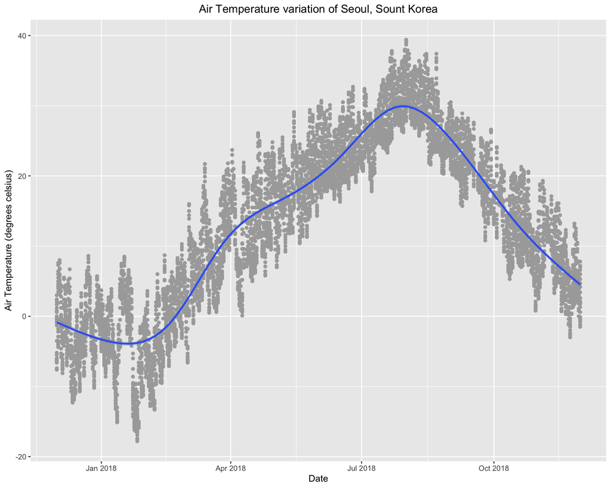

```r
## aligns the plot/figure in the center
## height/width gives size  in inches
ggplot(seoul_Bikes) +
  geom_point(aes(x = Date, y = Temperature), col="dark grey") +
  stat_smooth(aes(x = Date, y = Temperature)) + ## To see the distribution density
  xlab("Date") +  ## Naming x and y axes.
  ylab("Air Temperature (degrees celsius)") +
  ggtitle("Air Temperature variation of Seoul, Sount Korea") + ## Adding title to graph
  theme(plot.title = element_text(hjust = 0.5)) ## To align the title of the graph in the center, code fourd on stackoverflow :" https://stackoverflow.com/questions/40675778/center-plot-title-in-ggplot2 "
```

Using the point plot and a stat_smooth() we can view the Air Temperature’s distribution density of how the air temperature varies in Seoul, South Korea. There is a variety of temperature’s the warmest months are between may and august while the others get colder.

```r
## The mean average of air temperature.
seoul_Bikes %>%
  summarise(Mean=mean(Temperature))
```

```
##       Mean
## 1 12.77106
```

```r
## The hottest day
seoul_Bikes %>%
  summarise(Maximum=max(Temperature))
```

```
##   Maximum
## 1    39.4
```

```r
## The coldest day.
seoul_Bikes %>%
  summarise(Minimume=min(Temperature))
```

```
##   Minimume
## 1    -17.8
```

It can reach very hot days up to nearly 40 degrees cesius, but it can also be very cold nearly -18 degrees celsius.

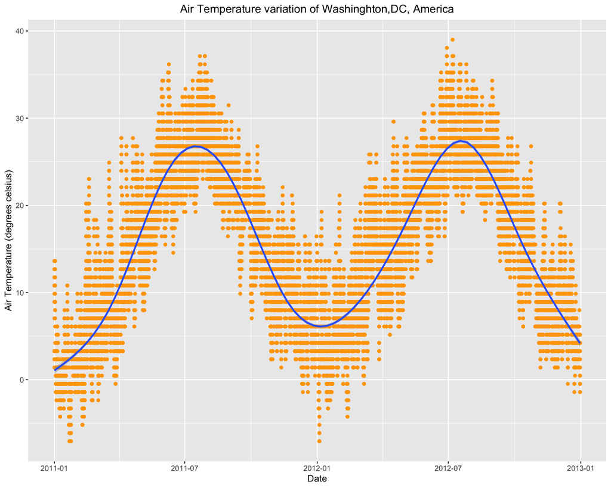

```r
ggplot(washington_Bikes) +
  geom_point(aes(x = Date, y = Temperature), col = "orange") +
  stat_smooth(aes(x = Date, y = Temperature)) +
  xlab("Date") +
  ylab("Air Temperature (degrees celsius)") +
  ggtitle("Air Temperature variation of Washinghton,DC, America") +
  theme(plot.title = element_text(hjust = 0.5))
```

Utilizing the point plot and a stat_smooth() we can view the Air Temperature’s distribution density of how the air temperature varies in Washinghton, DC. There is a similar density as Seoul. We can see the curve going up and back down two times. This is because the data in Washinghton’s is over two years rather than one year in Seou’s data.

```r
## The mean average of air temperature.
washington_Bikes %>%
  summarise(Mean=mean(Temperature))
```

```
##      Mean
## 1 15.3584
```

```r
## The hottest day
washington_Bikes %>%
  summarise(Maximum=max(Temperature))
```

```
##   Maximum
## 1      39
```

```r
## The coldest day.
washington_Bikes %>%
  summarise(Minimume=min(Temperature))
```

```
##   Minimume
## 1    -7.06
```

The average temperature in Washinghton is higher than Seoul. Both locations hotest days are close. But Seoul winter is a lot colder than Washinghton. We can see a difference of 10 degrees celsius.

#### Do seasons affect the average number of rented bikes?

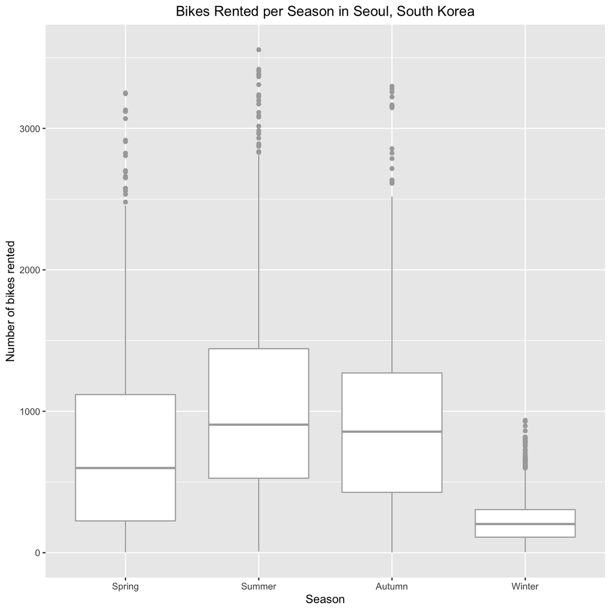

```r
ggplot(seoul_Bikes) +
  geom_boxplot(aes(x = Season, y = Count), col = "dark grey") +
  xlab("Season") +
  ylab("Number of bikes rented") +
  ggtitle("Bikes Rented per Season in Seoul, South Korea") +
  theme(plot.title = element_text(hjust = 0.5))
```

From the boxplot graph above we can observe there is a significant drop of bikes rented in the winter. The highest renting season is summer, although autumn and spring are not far behind. We can conclude that in Seoul, the bikes rented a day is depended on the season.

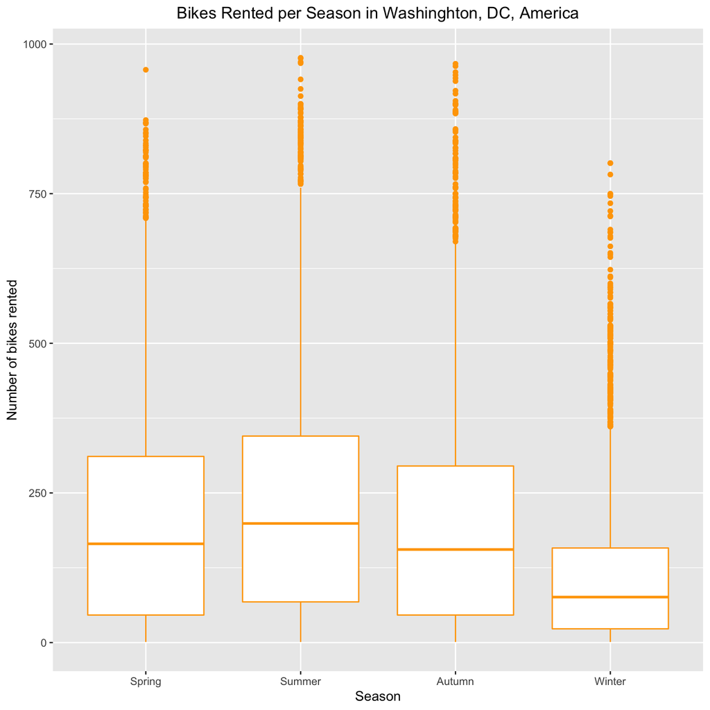

```r
ggplot(washington_Bikes) +
  geom_boxplot(aes(x = Season, y = Count), col = "orange") +
  xlab("Season") +
  ylab("Number of bikes rented") +
  ggtitle("Bikes Rented per Season in Washinghton, DC, America") +
  theme(plot.title = element_text(hjust = 0.5))
```

From the boxplot graph above we can observe there is a significant drop of bikes rented in the winter as well in Washington. The highest renting season is summer again, although autumn and spring are not far behind. We can conclude that for Washington, the bikes rented a day is depended on the season.  
Both locations are have a dramatic fall of rented bikes in the winter. We can conclude that the number of bikes of rented is depended on the season.

#### Do holidays increase or decrease the demand for rented bikes?

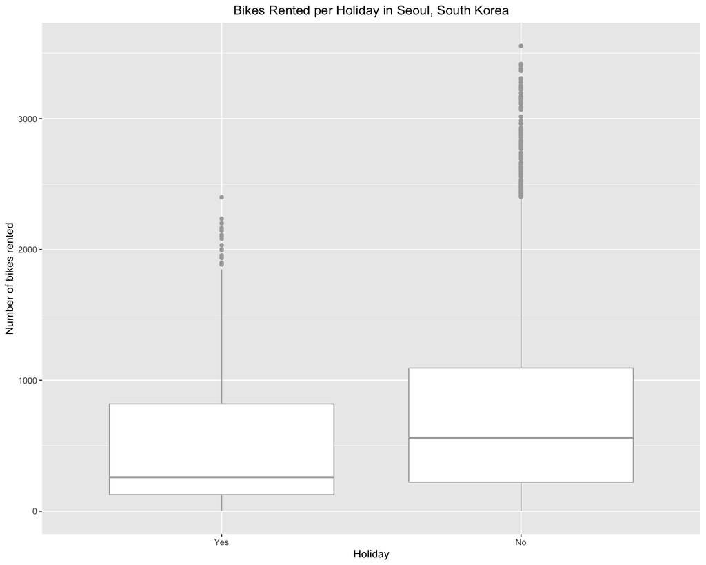

```r
ggplot(seoul_Bikes) +
  geom_boxplot(aes(x = Holiday, y = Count), col = "dark grey") +
  xlab("Holiday") +
  ylab("Number of bikes rented") +
  ggtitle("Bikes Rented per Holiday in Seoul, South Korea") +
  theme(plot.title = element_text(hjust = 0.5))
```

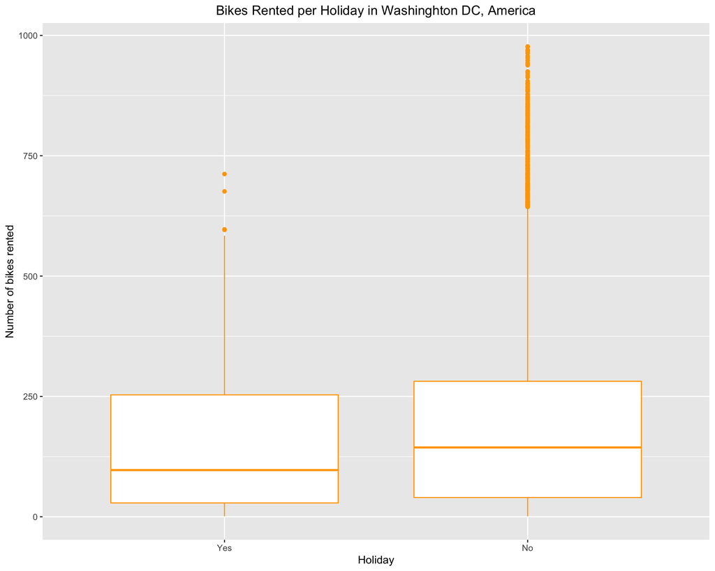

```r
ggplot(washington_Bikes) +
  geom_boxplot(aes(x = Holiday, y = Count), col = "orange") +
  xlab("Holiday") +
  ylab("Number of bikes rented") +
  ggtitle("Bikes Rented per Holiday in Washinghton DC, America") +
  theme(plot.title = element_text(hjust = 0.5))
```

By observing the two above boxplot graphs, we can sum up that more bikes are rented when there is not a holiday. There is a bigger difference of the number of bikes rented in the Seoul dataset. We can see that when its not a holiday there is big difference to the number of rented bikes. While in the America dataset, the difference is smaller.